# PA1 Template_ v2.0

## Loading and processing data

1. Load the data (i.e. 𝚛𝚎𝚊𝚍.𝚌𝚜𝚟())
2. Process/transform the data (if necessary) into a format suitable for your analysis

```r
d <- read.csv("./activity.csv",colClasses = c("numeric","Date","numeric"))
```

## What is mean total number of steps taken per day?

1. Calculate the total number of steps taken per day

```r
dsum <- tapply(d$steps,d$date,sum,na.rm=TRUE)
```

2. Make a histogram of the total number of steps taken each day

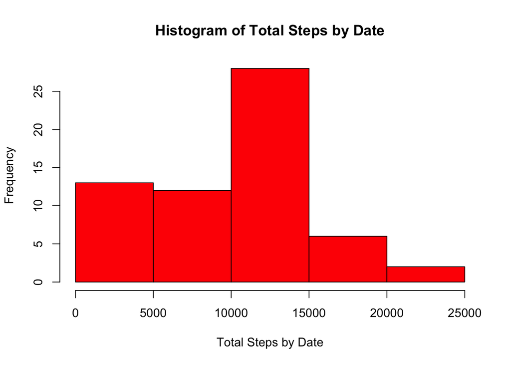

```r
hist(dsum,col="red",xlab="Total Steps by Date",main="Histogram of Total Steps by Date")
```

3. Calculate and report the mean and median of the total number of steps taken per day

3.1 Mean

```r
mean(dsum)
```

```
## [1] 9354.23
```

3.2 Median

```r
median(dsum)
```

```
## [1] 10395
```

## What is the average daily activity pattern?

1. Make a time series plot (i.e. 𝚝𝚢𝚙𝚎 = “𝚕”) of the 5-minute interval (x-axis) and the average number of steps taken, averaged across all days (y-axis)

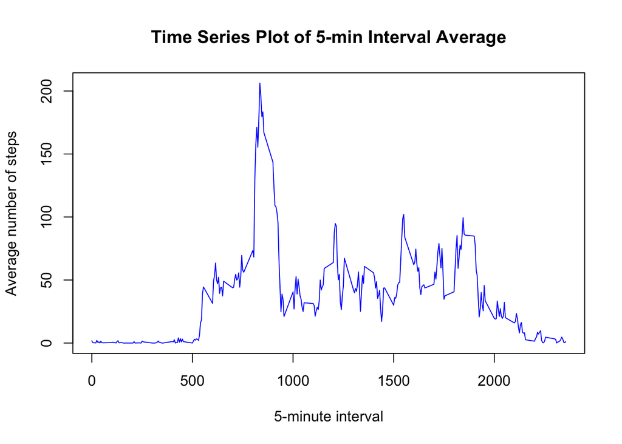

```r
daverage <- tapply(d$steps,d$interval,mean,na.rm=TRUE)
plot(names(daverage),daverage,type="l",xlab="5-minute interval",ylab="Average number of steps",main="Time Series Plot of 5-min Interval Average",col="blue")
```

2. Which 5-minute interval, on average across all the days in the dataset, contains the maximum number of steps?

```r
max_avg <- max(daverage)
n_match <- match(max_avg,daverage)
daverage[n_match]
```

```
##      835
## 206.1698
```

## Imputing missing values

1. Calculate and report the total number of missing values in the dataset

```r
sum(is.na(d))
```

```
## [1] 2304
```

2. Devise a strategy for filling in all of the missing values in the dataset. The strategy does not need to be sophisticated. For example, you could use the mean/median for that day, or the mean for that 5-minute interval, etc.

```r
dincomplete <- d[is.na(d),]
dcomplete <- d[complete.cases(d),]
dincomplete$steps <- as.numeric(daverage)
```

3. Create a new dataset that is equal to the original dataset but with the missing data filled in

```r
d1 <- rbind(dincomplete,dcomplete)
```

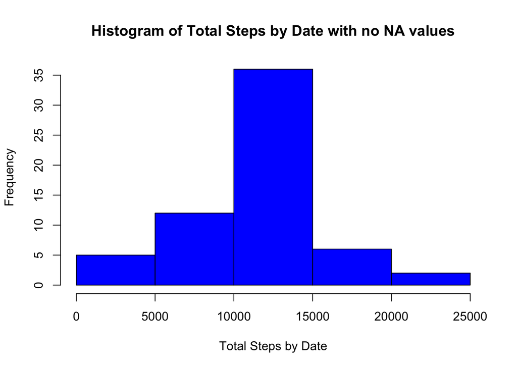

```r
dsum1 <- tapply(d1$steps,d1$date,sum,na.rm=TRUE)
hist(dsum1,col="blue",xlab="Total Steps by Date",main="Histogram of Total Steps by Date with no NA values")
```

```r
mean(dsum1)
```

```
## [1] 10766.19
```

```r
median(dsum1)
```

```
## [1] 10766.19
```

## Are there differences in activity patterns between weekdays and weekends?

1. Create a new factor variable in the dataset with two levels – “weekday” and “weekend” indicating whether a given date is a weekday or weekend day.

```r
weekenddays <- c("sábado","domingo")
d1$weekday <- factor((weekdays(d1$date) %in% weekenddays),levels=c(TRUE,FALSE),labels=c("weekend","weekday"))
d1weekdays <- d1$weekday == "weekday"
d1weekend <- d1$weekday == "weekend"
daverageweekday <- tapply(d1$steps[d1weekdays],as.factor(d1$interval[d1weekdays]),mean,na.rm=TRUE)
daverageweekend <- tapply(d1$steps[d1weekend],as.factor(d1$interval[d1weekend]),mean,na.rm=TRUE)
```

2. Make a panel plot containing a time series plot (i.e. 𝚝𝚢𝚙𝚎 = “𝚕”) of the 5-minute interval (x-axis) and the average number of steps taken, averaged across all weekday days or weekend days (y-axis). See the README file in the GitHub repository to see an example of what this plot should look like using simulated data.

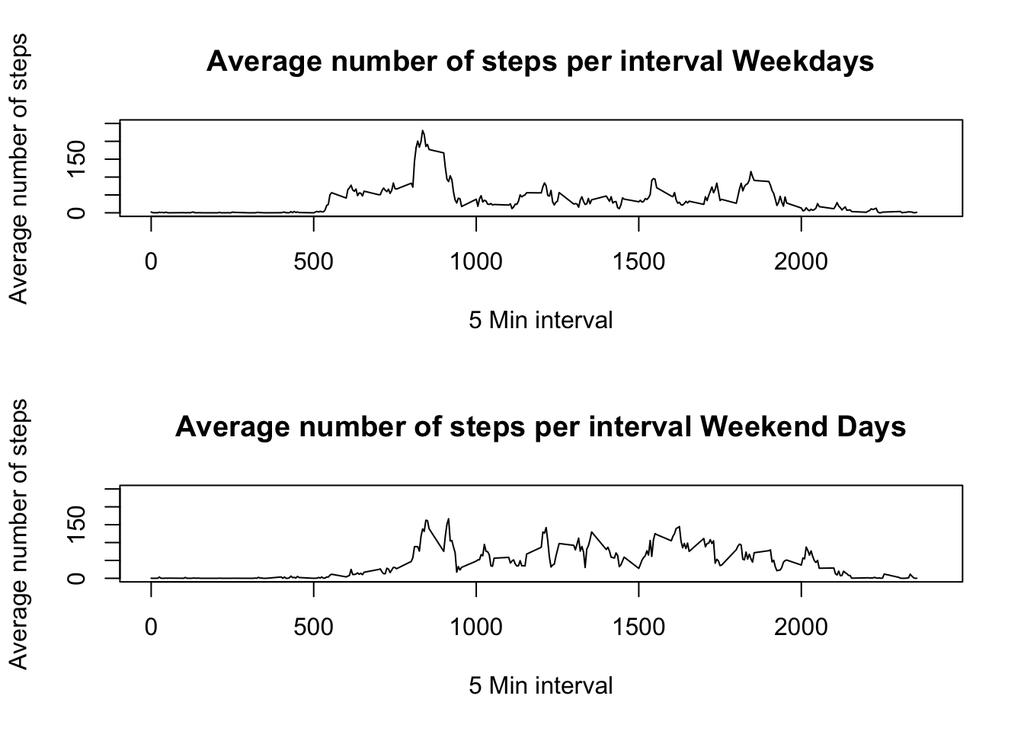

```r
par(mfcol = c(2, 1))
plot(names(daverageweekday), daverageweekday, type = "l", xlab = "5 Min interval", ylab = "Average number of steps", main = "Average number of steps per interval Weekdays",
     ylim = range(0:250), xlim = range(0:2400))
plot(names(daverageweekend), daverageweekend, type = "l", xlab = "5 Min interval", ylab = "Average number of steps", main = "Average number of steps per interval Weekend Days",
     ylim = range(0:250), xlim = range(0:2400))
```